# Predicting Boston House Prices Using Machine Learning in R

2023-02-16

Azdine Bahloul

Université Côte d’Azur

**Summary :**

# Introduction

**Data :**

The original data are 506 observations on 14 variables, cmedv being the target variable:

crim *per capita crime rate by town*

zn *proportion of residential land zoned for lots over 25,000 sq.ft*

indus *proportion of non-retail business acres per town*

chas *Charles River dummy variable (= 1 if tract bounds river; 0 otherwise)*

nox *nitric oxides concentration (parts per 10 million)*

rm *average number of rooms per dwelling age proportion of owner-occupied units built prior to 1940*

dis *weighted distances to five Boston employment centres*

rad *index of accessibility to radial highways*

tax *full-value property-tax rate per USD 10,000 ptratio pupil-teacher ratio by town*

b *1000(B - 0.63)^2 where B is the proportion of blacks by town*

lstat *percentage of lower status of the population*

medv *median value of owner-occupied homes in USD 1000’s*

The corrected data set has the following additional columns:

cmedv *corrected median value of owner-occupied homes in USD 1000’s*

town *name of town*

tract *census tract*

lon *longitude of census*

tract *lat latitude of census tract*

# Exploratory Analysis

## Data preprocessing: cleaning and validation

```r
data("BostonHousing2", package = "mlbench")

# Removal of unnecessary columns for our study
BostonHousing2 <- BostonHousing2[,-1]
BostonHousing2 <- BostonHousing2[,-4]
```

```r
# Check for missing values in all columns
sapply(BostonHousing2, function(x) sum(is.na(x)))
```

```
##   tract     lon     lat   cmedv    crim      zn   indus    chas     nox      rm
##       0       0       0       0       0       0       0       0       0       0
##     age     dis     rad     tax ptratio       b   lstat
##       0       0       0       0       0       0       0
```

```r
# Check for balance in our data
sapply(BostonHousing2, function(x) sum(!is.na(x)))
```

```
##   tract     lon     lat   cmedv    crim      zn   indus    chas     nox      rm
##     506     506     506     506     506     506     506     506     506     506
##     age     dis     rad     tax ptratio       b   lstat
##     506     506     506     506     506     506     506
```

```r
summary(BostonHousing2)
```

```
##      tract           lon              lat            cmedv
##  Min.   :   1   Min.   :-71.29   Min.   :42.03   Min.   : 5.00
##  1st Qu.:1303   1st Qu.:-71.09   1st Qu.:42.18   1st Qu.:17.02
##  Median :3394   Median :-71.05   Median :42.22   Median :21.20
##  Mean   :2700   Mean   :-71.06   Mean   :42.22   Mean   :22.53
##  3rd Qu.:3740   3rd Qu.:-71.02   3rd Qu.:42.25   3rd Qu.:25.00
##  Max.   :5082   Max.   :-70.81   Max.   :42.38   Max.   :50.00
##       crim                zn             indus       chas         nox
##  Min.   : 0.00632   Min.   :  0.00   Min.   : 0.46   0:471   Min.   :0.3850
##  1st Qu.: 0.08205   1st Qu.:  0.00   1st Qu.: 5.19   1: 35   1st Qu.:0.4490
##  Median : 0.25651   Median :  0.00   Median : 9.69           Median :0.5380
##  Mean   : 3.61352   Mean   : 11.36   Mean   :11.14           Mean   :0.5547
##  3rd Qu.: 3.67708   3rd Qu.: 12.50   3rd Qu.:18.10           3rd Qu.:0.6240
##  Max.   :88.97620   Max.   :100.00   Max.   :27.74           Max.   :0.8710
##        rm             age              dis              rad
##  Min.   :3.561   Min.   :  2.90   Min.   : 1.130   Min.   : 1.000
##  1st Qu.:5.886   1st Qu.: 45.02   1st Qu.: 2.100   1st Qu.: 4.000
##  Median :6.208   Median : 77.50   Median : 3.207   Median : 5.000
##  Mean   :6.285   Mean   : 68.57   Mean   : 3.795   Mean   : 9.549
##  3rd Qu.:6.623   3rd Qu.: 94.08   3rd Qu.: 5.188   3rd Qu.:24.000
##  Max.   :8.780   Max.   :100.00   Max.   :12.127   Max.   :24.000
##       tax           ptratio            b              lstat
##  Min.   :187.0   Min.   :12.60   Min.   :  0.32   Min.   : 1.73
##  1st Qu.:279.0   1st Qu.:17.40   1st Qu.:375.38   1st Qu.: 6.95
##  Median :330.0   Median :19.05   Median :391.44   Median :11.36
##  Mean   :408.2   Mean   :18.46   Mean   :356.67   Mean   :12.65
##  3rd Qu.:666.0   3rd Qu.:20.20   3rd Qu.:396.23   3rd Qu.:16.95
##  Max.   :711.0   Max.   :22.00   Max.   :396.90   Max.   :37.97
```

```r
head(BostonHousing2)
```

|  | tract | lon | lat | cmedv | crim | zn | indus | chas | nox | rm | age | dis | rad | tax | ptratio | b | lstat |
| --- | --- | --- | --- | --- | --- | --- | --- | --- | --- | --- | --- | --- | --- | --- | --- | --- | --- |
| 1 | 2011 | -70.9550 | 42.2550 | 24.0 | 0.00632 | 18 | 2.31 | 0 | 0.538 | 6.575 | 65.2 | 4.0900 | 1 | 296 | 15.3 | 396.90 | 4.98 |
| 2 | 2021 | -70.9500 | 42.2875 | 21.6 | 0.02731 | 0 | 7.07 | 0 | 0.469 | 6.421 | 78.9 | 4.9671 | 2 | 242 | 17.8 | 396.90 | 9.14 |
| 3 | 2022 | -70.9360 | 42.2830 | 34.7 | 0.02729 | 0 | 7.07 | 0 | 0.469 | 7.185 | 61.1 | 4.9671 | 2 | 242 | 17.8 | 392.83 | 4.03 |
| 4 | 2031 | -70.9280 | 42.2930 | 33.4 | 0.03237 | 0 | 2.18 | 0 | 0.458 | 6.998 | 45.8 | 6.0622 | 3 | 222 | 18.7 | 394.63 | 2.94 |
| 5 | 2032 | -70.9220 | 42.2980 | 36.2 | 0.06905 | 0 | 2.18 | 0 | 0.458 | 7.147 | 54.2 | 6.0622 | 3 | 222 | 18.7 | 396.90 | 5.33 |
| 6 | 2033 | -70.9165 | 42.3040 | 28.7 | 0.02985 | 0 | 2.18 | 0 | 0.458 | 6.430 | 58.7 | 6.0622 | 3 | 222 | 18.7 | 394.12 | 5.21 |

```r
str(BostonHousing2)
```

```
## 'data.frame':    506 obs. of  17 variables:
##  $ tract  : int  2011 2021 2022 2031 2032 2033 2041 2042 2043 2044 ...
##  $ lon    : num  -71 -71 -70.9 -70.9 -70.9 ...
##  $ lat    : num  42.3 42.3 42.3 42.3 42.3 ...
##  $ cmedv  : num  24 21.6 34.7 33.4 36.2 28.7 22.9 22.1 16.5 18.9 ...
##  $ crim   : num  0.00632 0.02731 0.02729 0.03237 0.06905 ...
##  $ zn     : num  18 0 0 0 0 0 12.5 12.5 12.5 12.5 ...
##  $ indus  : num  2.31 7.07 7.07 2.18 2.18 2.18 7.87 7.87 7.87 7.87 ...
##  $ chas   : Factor w/ 2 levels "0","1": 1 1 1 1 1 1 1 1 1 1 ...
##  $ nox    : num  0.538 0.469 0.469 0.458 0.458 0.458 0.524 0.524 0.524 0.524 ...
##  $ rm     : num  6.58 6.42 7.18 7 7.15 ...
##  $ age    : num  65.2 78.9 61.1 45.8 54.2 58.7 66.6 96.1 100 85.9 ...
##  $ dis    : num  4.09 4.97 4.97 6.06 6.06 ...
##  $ rad    : int  1 2 2 3 3 3 5 5 5 5 ...
##  $ tax    : int  296 242 242 222 222 222 311 311 311 311 ...
##  $ ptratio: num  15.3 17.8 17.8 18.7 18.7 18.7 15.2 15.2 15.2 15.2 ...
##  $ b      : num  397 397 393 395 397 ...
##  $ lstat  : num  4.98 9.14 4.03 2.94 5.33 ...
```

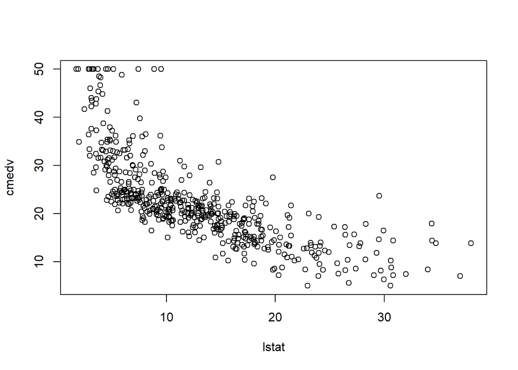

```r
plot(cmedv~lstat, BostonHousing2)
```

We indeed, and as expected, have a correlation between the percentage of lower status of the population (lstat) and median value of owner-occupied homes in USD 1000’s (cmedv). The relation is likely to be non-linear.

## Data Analysis

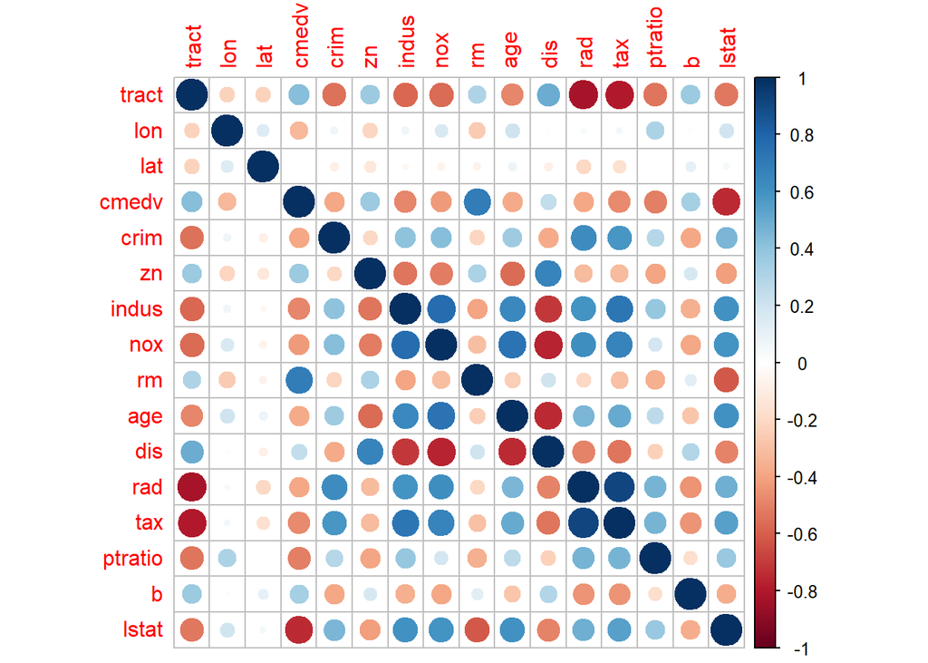

```r
BostonHousing2 %>%
  select_if(is.numeric) %>%
  cor() %>%
  corrplot()
```

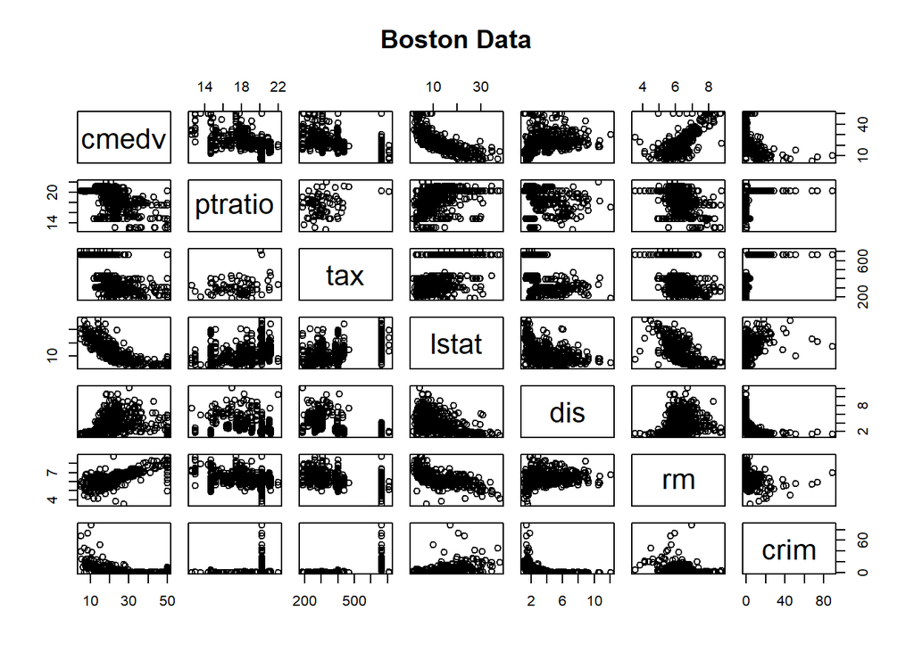

```r
pairs(~ cmedv + ptratio + tax + lstat + dis + rm + crim, data = BostonHousing2, main = "Boston Data")
```

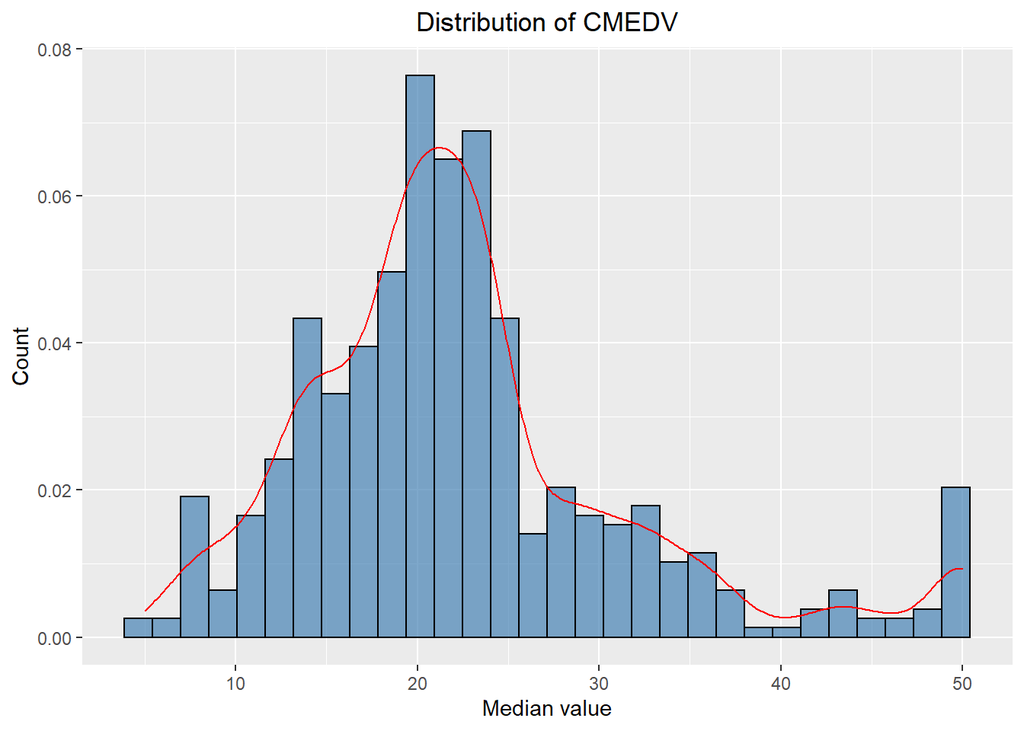

```r
ggplot(BostonHousing2, aes(x = cmedv)) +
  geom_histogram(aes(y = ..density..), fill = "steelblue", alpha = 0.7, color = "black") +
  geom_density(color="red", position = "identity") +
  labs(x = "Median value", y = "Count") +
  ggtitle("Distribution of CMEDV") +
  theme(plot.title = element_text(hjust = 0.5))
```

The density is represented by the red curve. We can observe that the median price of a home is skewed to the right, with several outliers.

Checking the dependent variable’s correlation with input characteristics and any features that have close to zero variance are two crucial criteria to verify now (values not varying much within the column).

```r
correlations <- cor(BostonHousing2[, sapply(BostonHousing2, is.numeric)], BostonHousing2$cmedv, method = "pearson")
correlations
```

```
##                 [,1]
## tract    0.428251535
## lon     -0.322946685
## lat      0.006825792
## cmedv    1.000000000
## crim    -0.389582441
## zn       0.360386177
## indus   -0.484754379
## nox     -0.429300219
## rm       0.696303794
## age     -0.377998896
## dis      0.249314834
## rad     -0.384765552
## tax     -0.471978807
## ptratio -0.505654619
## b        0.334860832
## lstat   -0.740835993
```

In contrast to the percentage of the population with lower socioeconomic level (lstat) and the pupil-teacher ratio (ptratio), which have substantial negative correlations, the number of rooms (rm) has the largest positive correlation with the median value of the home price. The lat is the characteristic that correlates least with cmedv. Although it might be “chas,” we must convert the data to “num” in order to notice the correlation.

```r
nofzv <- nearZeroVar(BostonHousing2, saveMetrics = TRUE)
sum(nofzv$nofzv)
```

```
## [1] 0
```

The results demonstrate that there are no variables with variances of 0 or nearly zero.

# Regression models

## Linear Regression

Let’s attempt a generalized linear regression model first, with the dependent variable cmedv and all the other variables acting as independent variables. Using the training dataset, we train the model. The coefficients of each feature and the intercept for this linear model are listed below. The outcome (cmedv) for the testing dataset is then predicted using the trained model. Calculating the root-mean squared error is a useful metric for evaluating the model’s precision.

```r
fit.lm <- lm(cmedv~.,data = train)

#check coeffs
data.frame(coef = round(fit.lm$coefficients,2))
```

|  | coef |
| --- | --- |
| (Intercept) | -159.49 |
| tract | 0.00 |
| lon | -5.19 |
| lat | -4.00 |
| crim | -0.07 |
| zn | 0.05 |
| indus | 0.01 |
| chas1 | 2.52 |
| nox | -16.41 |
| rm | 3.27 |

[output cut: 7 more lines]

```r
#predict on test set
pred.lm <- predict(fit.lm, newdata = test)

# Root-mean squared error
rmse.lm <- sqrt(sum((pred.lm - test$cmedv)^2)/
                  length(test$cmedv))

c(RMSE = rmse.lm, R2 = summary(fit.lm)$r.squared)
```

```
##      RMSE        R2
## 4.8131652 0.7372172
```

We see that the RMSE is 4.8 and the R2 value is 0.74 for this model.

The output variable, cmedv, was skewed to the right, as we have seen. The distribution of cmedv would be normalized by using a log transformation. Let’s run glm with all remaining features as input and log(cmedv) as the output. We can observe that this model’s RMSE value has decreased.

## Log-linear Regression 1

```r
set.seed(12345)
#Try linear model using all features
fit.lm1 <- lm(log(cmedv)~.,data = train)

set.seed(12345)
#predict on test set
pred.lm1 <- predict(fit.lm1, newdata = test)

# Root-mean squared error
rmse.lm1 <- sqrt(sum((exp(pred.lm1) - test$cmedv)^2)/
                   length(test$cmedv))

c(RMSE = rmse.lm1, R2 = summary(fit.lm1)$r.squared)
```

```
##      RMSE        R2
## 4.2867040 0.7938755
```

Thoses predictions are slightly better since we have an increase in R2 and decrease in RMSE. Let us examine the calculated p-value for each feature in the linear model. Any feature which is not significant (p<0.05) is not contributing signicantly for the model, probably due to multicollinearity among other features. We see that the features, tract, lon, lat and indus are not significant.

```r
summary(fit.lm1)
```

```
##
## Call:
## lm(formula = log(cmedv) ~ ., data = train)
##
## Residuals:
##      Min       1Q   Median       3Q      Max
## -0.71899 -0.10638 -0.00418  0.09714  0.87342
##
## Coefficients:
##               Estimate Std. Error t value Pr(>|t|)
## (Intercept) -1.463e+01  1.446e+01  -1.012 0.312344
## tract       -5.852e-06  1.979e-05  -0.296 0.767650
## lon         -2.474e-01  1.519e-01  -1.629 0.104036
## lat          2.767e-02  2.381e-01   0.116 0.907530
## crim        -9.786e-03  1.863e-03  -5.253 2.47e-07 ***
## zn           1.367e-03  6.137e-04   2.228 0.026461 *
## indus        1.968e-03  2.719e-03   0.724 0.469755
## chas1        1.004e-01  3.813e-02   2.634 0.008779 **
## nox         -7.072e-01  1.863e-01  -3.795 0.000171 ***
## rm           7.121e-02  1.798e-02   3.961 8.86e-05 ***
## age          1.472e-03  5.979e-04   2.461 0.014288 *
## dis         -3.856e-02  9.336e-03  -4.130 4.44e-05 ***
## rad          1.439e-02  3.923e-03   3.669 0.000277 ***
## tax         -6.730e-04  1.728e-04  -3.895 0.000116 ***
## ptratio     -3.520e-02  6.266e-03  -5.617 3.70e-08 ***
## b            3.227e-04  1.211e-04   2.664 0.008049 **
## lstat       -3.333e-02  2.224e-03 -14.992  < 2e-16 ***
## ---
## Signif. codes:  0 '***' 0.001 '**' 0.01 '*' 0.05 '.' 0.1 ' ' 1
##
## Residual standard error: 0.1876 on 390 degrees of freedom
## Multiple R-squared:  0.7939, Adjusted R-squared:  0.7854
## F-statistic: 93.88 on 16 and 390 DF,  p-value: < 2.2e-16
```

```r
vif(fit.lm1)
```

```
##     tract       lon       lat      crim        zn     indus      chas       nox
##  8.717470  1.533373  2.507121  2.229370  2.330920  3.931234  1.112614  5.165486
##        rm       age       dis       rad       tax   ptratio         b     lstat
##  1.831228  3.337973  4.488709 13.811832  9.978556  2.059640  1.496481  2.946187
```

For calculating the standard errors of estimates for the coefficients of a linear model, vif() computes the variance inflation factors. The vif for each feature must be less than 5, at all times. We can observe that for tract, nox, rad, and tax, the vif is higher than 5.

## Log-linear regression 2

Based on all these observations, we now construct a new linear model as below:

```r
set.seed(12345)
#Try simple linear model using selected features
fit.lm2 <- lm(formula = log(cmedv) ~ crim + chas + nox + rm + dis + ptratio +
                rad + b + lstat, data = train)

set.seed(12345)
#predict on test set
pred.lm2 <- predict(fit.lm2, newdata = test)

# Root-mean squared error
rmse.lm2 <- sqrt(sum((exp(pred.lm2) - test$cmedv)^2)/
                   length(test$cmedv))

c(RMSE = rmse.lm2, R2 = summary(fit.lm2)$r.squared)
```

```
##      RMSE        R2
## 4.2940413 0.7809663
```

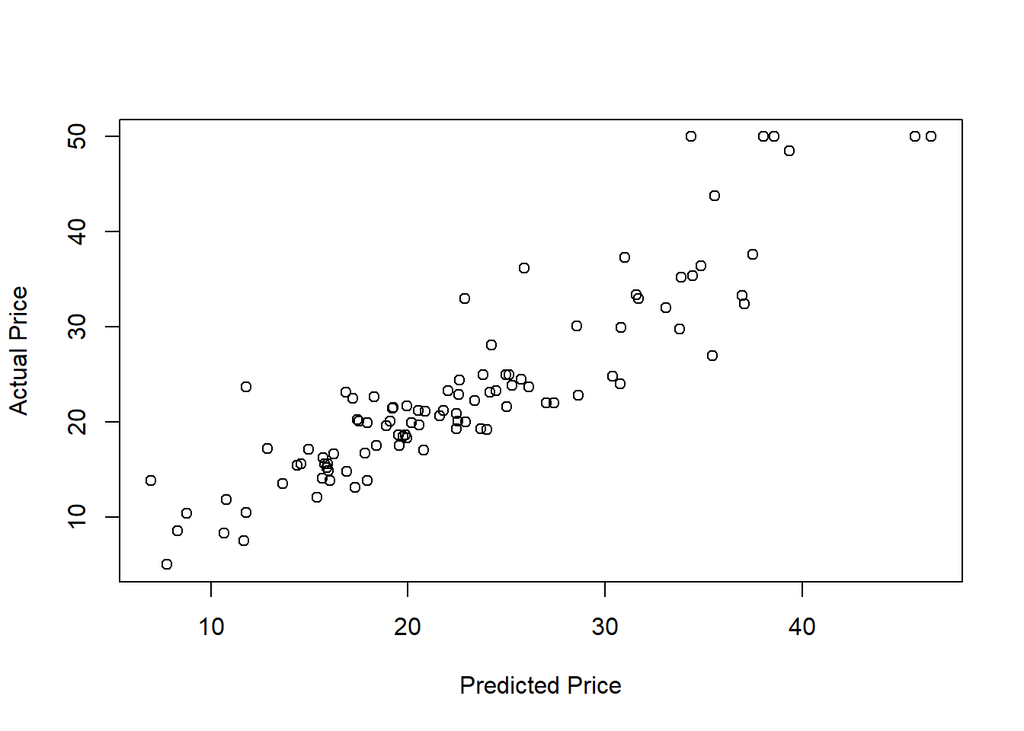

```r
# Plot of predicted price vs actual price
plot(exp(pred.lm2),test$cmedv, xlab = "Predicted Price", ylab = "Actual Price")
```

# Other regressions

## Rpart, Tree-based and Random Forest models

The linear model formula of PRICE (which states that PRICE is the outcome with all other features as input including cmedv, which is our aim) might be used for rpart, tree, and random forest implementations. Looking at the data, we can see that the random forest model has provided the most accurate results to date.

Also, we created a new column to our dataset named “price” that has the same values as the “cmedv” variable. This was done in order to make our study more understandable and since we found that our models performed worse when we used “cmedv” as the target variable explicitly. Our models are better able to capture the links between the other factors in the dataset and the target variable by utilizing “price” as the target variable.

```r
BostonHousing2$PRICE <- BostonHousing2$cmedv
```

```r
#Creations of classifiers
model1 <- rpart(PRICE ~ ., train)
modeltree <- tree(PRICE ~ .,train)
modelRtree <- randomForest(PRICE ~ . ,train)


#Application of classifiers to the test set
test_model1 <- predict(model1, test)
test_modeltree <- predict(modeltree,test)
test_modelRtree <- predict(modelRtree, test)

#Addition of columns with predictions from the first three classifiers to the test data:
test$model1 <- test_model1
test$modeltree <- test_modeltree
test$modelRtree <- test_modelRtree
```

```r
#4) Evaluation of classifiers

#LOSS FUNCTION

# Calculation of MSE, RMSE and MAE models 1, 2 et 3
mse1 <- mean((test$PRICE - test$model1)^2)
rmse1 <- sqrt(mean((test$PRICE - test$model1)^2))
mae1 <- mean(abs(test$PRICE - test$model1))

mse2 <- mean((test$PRICE - test$modeltree)^2)
rmse2 <- sqrt(mean((test$PRICE - test$modeltree)^2))
mae2 <- mean(abs(test$PRICE - test$modeltree))

mse3 <- mean((test$PRICE - test$modelRtree)^2)
rmse3 <- sqrt(mean((test$PRICE - test$modelRtree)^2))
mae3 <- mean(abs(test$PRICE - test$modelRtree))
```

```r
# Find the model with MSE, RMSE et MAE minimum
best_mse <- min(mse1, mse2, mse3)
best_rmse <- min(rmse1, rmse2, rmse3)
best_mae <- min(mae1, mae2, mae3)

# Conclusion
cat("The model with the smallest MSE is :", ifelse(best_mse == mse1, "model1", ifelse(best_mse == mse2, "modeltree", "modelRtree")), "\n")
```

```
## The model with the smallest MSE is : modelRtree
```

```r
cat("The model with the smallest RMSE is :", ifelse(best_rmse == rmse1, "model1", ifelse(best_rmse == rmse2, "modeltree", "modelRtree")), "\n")
```

```
## The model with the smallest RMSE is : modelRtree
```

```r
cat("The model with the smallest MAE is :", ifelse(best_mae == mae1, "model1", ifelse(best_mae == mae2, "modeltree", "modelRtree")), "\n")
```

```
## The model with the smallest MAE is : modelRtree
```

```r
#Other metrics to evaluate models

# Calculation of R squared
rsq1 <- 1 - sum((test$PRICE - test$model1)^2) / sum((test$PRICE - mean(test$PRICE))^2)
rsq2 <- 1 - sum((test$PRICE - test$modeltree)^2) / sum((test$PRICE - mean(test$PRICE))^2)
rsq3 <- 1 - sum((test$PRICE - test$modelRtree)^2) / sum((test$PRICE - mean(test$PRICE))^2)

# Calculation of Adjusted R squared
adj_rsq1 <- 1 - (1 - rsq1) * (nrow(test) - 1) / (nrow(test) - ncol(test) - 1)
adj_rsq2 <- 1 - (1 - rsq2) * (nrow(test) - 1) / (nrow(test) - ncol(test) - 1)
adj_rsq3 <- 1 - (1 - rsq3) * (nrow(test) - 1) / (nrow(test) - ncol(test) - 1)
```

```r
if (adj_rsq1 > adj_rsq2 && adj_rsq1 > adj_rsq3) {
  cat("The model with the highest adjusted R-squared is Rpart.\n")
} else if (adj_rsq2 > adj_rsq1 && adj_rsq2 > adj_rsq3) {
  cat("The model with the highest adjusted R-squared is Tree-based 2.\n")
} else if (adj_rsq3 > adj_rsq1 && adj_rsq3 > adj_rsq2) {
  cat("The model with the highest adjusted R-squared is Random Forest.\n")
  cat("The adjusted R-squared is equal to: ", max(adj_rsq1, adj_rsq2, adj_rsq3), "\n")
} else {
  cat("There is a tie for the model with the highest adjusted R-squared.\n")
}
```

```
## The model with the highest adjusted R-squared is Random Forest.
## The adjusted R-squared is equal to:  0.9748579
```

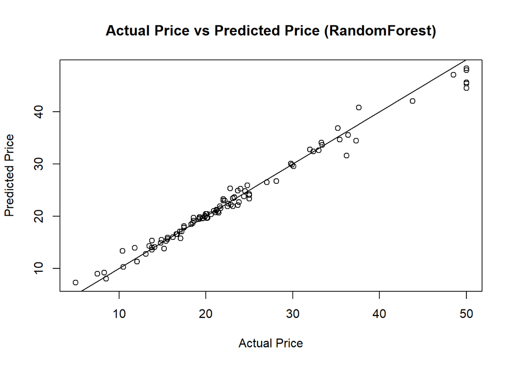

```r
plot(test$PRICE, test$modelRtree, main = "Actual Price vs Predicted Price (RandomForest)",
     xlab = "Actual Price", ylab = "Predicted Price")
abline(a = 0, b = 1)
```

# Conclusion

To estimate the home prices in the Boston suburbs, we tested with a variety of linear regression, tree-based, and random forest models. The best model to predict the outcome with the least RMSE was a random forest model with a straightforward linear relationship between the outcome and all input characteristics.